# Introduction to Data Science

Mahbubul Majumder  
Aug 26, 2014

### Course information

- Lecture: DSC 256
- Time: Tuesdays and Thursdays, 5:30PM - 6:45PM
- Textbook: notes and resources  
  many links !
- Course page: Blackboard

### About me

- Call me Mah-bub
- Office: DSC 238
- Phone: (402) 554-2734
- Email: mmajumder@unomaha.edu (preferable)
- Office hour: Tuesdays and Thursdays, 4:00PM - 5:30PM
- Add me in Linkedin

### I can't eat data

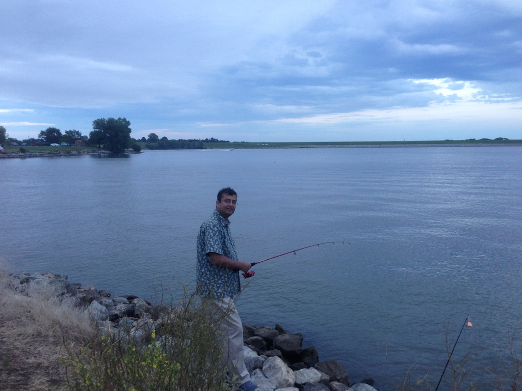

### Course outline

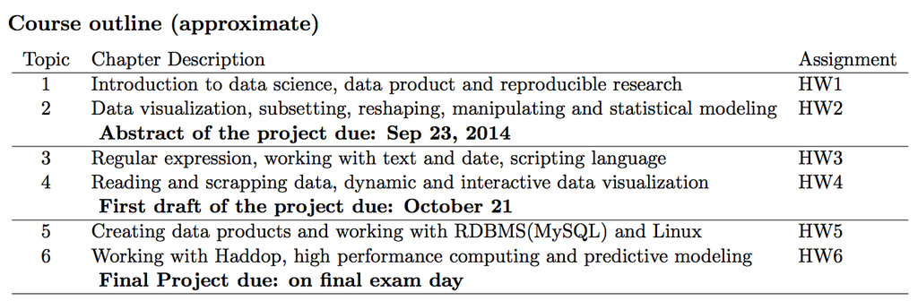

### Respond to homework0

A homewrok number zero is uploaded

- Will not be graded
- Be used for creating project group
- Serve as testing of blackboard

### Homeworks

There will be six homeworks through the semester

- Each carries 15 points (total 90 points)
- Can work in groups, but turn in individual work
- No late homeworks !

### Project Description

No exam! Submit a group project

- Form group by next week
- Each group consists of 4/5 students
- Submit real data project
- Sep 23: Abstract due
- Oct 21: Draft due
- Dec —-: Final project
- Dec —-: Project presentation

### Why project?

- Most of your Interview questions will be on the project
- Get your future career under shape (Faten your CV)
- The reality teaches in many ways that nobody can
- Be confident

### How does a project die?

How do you think a project dies after you have submitted and got grades on it?

- Throw it out and don't look back again
- Not reproducible and lazy to do it again
- Sit and see what others did on the group and you don't have a feel for it
- No future plan with it
- Fear competition
- Don't want to participate [data expo](http://stat-computing.org/dataexpo/)

### Other assignments

- Recommended reading
- Class worksheets
- Check blackboard !

### Grading

- Point distribution

```
          task points
      Homework     90
      Abstract     60
 Draft Project     60
 Final Project     60
  Presentation     30
         Total    300
```

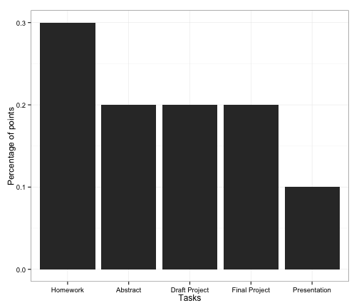

- Letter grade

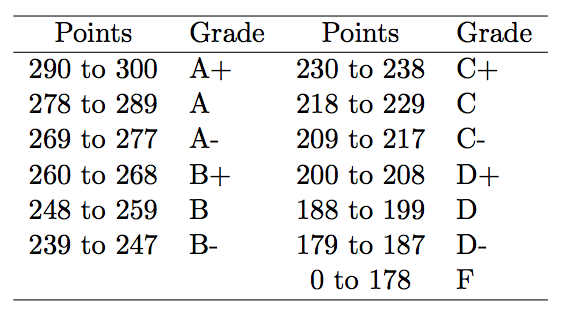

### Data Science lab

The data science lab location: DSC 243

- Data science tools are available
- Can get access to high performance computing (HCC)
- Lab user manual
- You can prepare your own machine (like the lab) for small task
- How to prepare a data science lab !

### Install R and RStudio

The data science lab has both R and RStudio installed

- Get R from http://cran.r-project.org/
- Install a typesetting software latex or Miktex from http://miktex.org/download  
  for MAC user it would be MacTex
- Get RStudio desktop version from http://www.rstudio.com/
- RStuio provides convenient environment. Lot more is going on than you think
- Its all free

### Benefit from this course

- Tools and Technics of data science
- How to create data product
- Reproducible analysis of data
- Your own data analysis project
- Contribute to a data driven society
- Not scared of data
- Not shy of data

### A sample email received yesterday

Mahbubul,

I just wanted to introduce myself. My name is X-Y-Z - I am data scientist at J-K-L and I am really excited to see that UNO is offering a Data Science Concentration. We’re looking for a data science intern(s) right now, so if you have any interested students, they can ping me. Also, I’d love to find ways to collaborate with UNO if that’s something that would be helpful or interesting to you. I hope your course goes well this semester!

X-Y

X-Y-Z  
J-K-L | Data Scientist  
@J-K-L | @x-y-z